# 6.3 Geographical Visualizations

## **6.3: Geographical Visualizations**

### **Contents**

1. Importing Libraries for Visualization and Geospatial Analysis
2. Importing Analysis Data
3. Data Wrangling/Data Cleaning
4. Plotting Choropleth
5. Summary

### **1. Importing Libraries for Visualization and Geospatial Analysis**

```python
# Importing libraries

import pandas as pd
import numpy as np
import os
import matplotlib.pyplot as plt
import seaborn as sns
import scipy
import matplotlib.ticker as mtick
import folium
import json
```

### **2. Importing Analysis Data**

**- Import JSON File**

```python
# Create data path
path = r'/Users/anjanpakhrin/Documents/US Accidents Analysis 2016-2023'
```

```python
# Import JSON file
usa_geo = os.path.join(path, '02 Data', 'Original Data', 'us-states.json')
```

**- Display JSON contents**

```python
# Path to JSON file
f = open(usa_geo)

# Returns JSON object asa dictionary
data = json.load(f)

# Iterating through the json list
for i in data['features']:
    print(i)
```

[output not shown]

[output cut: 36 more lines]

**- Import DataFrame**

```python
# Importing cleaned DataFrame from previous step
df = pd.read_pickle(os.path.join(path, '02 Data', 'Prepared Data', 'us_accidents_6-2.pkl'))
```

```python
# Checking output
df.head(2)
```

|  | id | source | severity | start_time | end_time | distance(mi) | state | temperature(f) | wind_chill(f) | humidity(%) | ... | astronomical_twilight | month | month_name | day_of_week | accident_day | accident_hour | time_of_day | severity_label | extreme_flag | year |
| --- | --- | --- | --- | --- | --- | --- | --- | --- | --- | --- | --- | --- | --- | --- | --- | --- | --- | --- | --- | --- | --- |
| 0 | A-1 | Source2 | 3 | 2016-02-08 05:46:00 | 2016-02-08 11:00:00 | 0.01 | OH | 36.900002 | 0.0 | 91.0 | ... | Night | 2 | February | 0 | Monday | 5 | Night | Serious | False | 2016 |
| 1 | A-2 | Source2 | 2 | 2016-02-08 06:07:59 | 2016-02-08 06:37:59 | 0.01 | OH | 37.900002 | 0.0 | 100.0 | ... | Day | 2 | February | 0 | Monday | 6 | Morning | Moderate | False | 2016 |

2 rows × 29 columns

### **3. Data Wrangling/Cleaning**

**3.1: Check for Missing Values**

```python
# Check for missing values
df.isnull().sum()
```

```
id                       0
source                   0
severity                 0
start_time               0
end_time                 0
distance(mi)             0
state                    0
temperature(f)           0
wind_chill(f)            0
humidity(%)              0
pressure(in)             0
visibility(mi)           0
wind_direction           0
wind_speed(mph)          0
precipitation(in)        0
weather_condition        0
sunrise_sunset           0
civil_twilight           0
nautical_twilight        0
astronomical_twilight    0
month                    0
month_name               0
day_of_week              0
accident_day             0
accident_hour            0
time_of_day              0
severity_label           0
extreme_flag             0
year                     0
dtype: int64
```

**3.2: Renaming State Name in Proper Form**

**- Check Unique Values in Column "state"**

```python
# Check unique values in "state"
state_list = df['state'].unique().tolist()
print("All unique state values:")
print(state_list)
print(f"Total: {len(state_list)} states")
```

```
All unique state values:
['OH', 'WV', 'CA', 'FL', 'GA', 'SC', 'NE', 'IA', 'IL', 'MO', 'WI', 'IN', 'MI', 'NJ', 'NY', 'CT', 'MA', 'RI', 'NH', 'PA', 'KY', 'MD', 'VA', 'DC', 'DE', 'TX', 'WA', 'OR', 'AL', 'NC', 'AZ', 'TN', 'LA', 'MN', 'CO', 'OK', 'NV', 'UT', 'KS', 'NM', 'AR', 'MS', 'ME', 'VT', 'WY', 'ID', 'ND', 'MT', 'SD']
Total: 49 states
```

**-Create Dictionary Mapping**

```python
# Create a dictionary mapping abbreviations to full names
state_mapping = {
    'AL': 'Alabama', 'AR': 'Arkansas', 'AZ': 'Arizona', 'CA': 'California',
    'CO': 'Colorado', 'CT': 'Connecticut', 'DC': 'District of Columbia', 'DE': 'Delaware',
    'FL': 'Florida', 'GA': 'Georgia', 'IA': 'Iowa', 'ID': 'Idaho',
    'IL': 'Illinois', 'IN': 'Indiana', 'KS': 'Kansas', 'KY': 'Kentucky',
    'LA': 'Louisiana', 'MA': 'Massachusetts', 'MD': 'Maryland', 'ME': 'Maine',
    'MI': 'Michigan', 'MN': 'Minnesota', 'MO': 'Missouri', 'MS': 'Mississippi',
    'MT': 'Montana', 'NC': 'North Carolina', 'ND': 'North Dakota', 'NE': 'Nebraska',
    'NH': 'New Hampshire', 'NJ': 'New Jersey', 'NM': 'New Mexico', 'NV': 'Nevada',
    'NY': 'New York', 'OH': 'Ohio', 'OK': 'Oklahoma', 'OR': 'Oregon',
    'PA': 'Pennsylvania', 'RI': 'Rhode Island', 'SC': 'South Carolina', 'SD': 'South Dakota',
    'TN': 'Tennessee', 'TX': 'Texas', 'UT': 'Utah', 'VA': 'Virginia',
    'VT': 'Vermont', 'WA': 'Washington', 'WI': 'Wisconsin', 'WV': 'West Virginia',
    'WY': 'Wyoming'
}
```

**- Convert State Abbreviations to Full Name**

```python
# Copy dataframe
df = df.copy()

# Convert state abbreviations to full names
df['state'] = df['state'].map(state_mapping)
```

```python
# Verify the conversion
df.head(2)
```

|  | id | source | severity | start_time | end_time | distance(mi) | state | temperature(f) | wind_chill(f) | humidity(%) | ... | astronomical_twilight | month | month_name | day_of_week | accident_day | accident_hour | time_of_day | severity_label | extreme_flag | year |
| --- | --- | --- | --- | --- | --- | --- | --- | --- | --- | --- | --- | --- | --- | --- | --- | --- | --- | --- | --- | --- | --- |
| 0 | A-1 | Source2 | 3 | 2016-02-08 05:46:00 | 2016-02-08 11:00:00 | 0.01 | Ohio | 36.900002 | 0.0 | 91.0 | ... | Night | 2 | February | 0 | Monday | 5 | Night | Serious | False | 2016 |
| 1 | A-2 | Source2 | 2 | 2016-02-08 06:07:59 | 2016-02-08 06:37:59 | 0.01 | Ohio | 37.900002 | 0.0 | 100.0 | ... | Day | 2 | February | 0 | Monday | 6 | Morning | Moderate | False | 2016 |

2 rows × 29 columns

**3.3: Check for Missing Values**

```python
# Check for missing values
df.isnull().sum()
```

```
id                       0
source                   0
severity                 0
start_time               0
end_time                 0
distance(mi)             0
state                    0
temperature(f)           0
wind_chill(f)            0
humidity(%)              0
pressure(in)             0
visibility(mi)           0
wind_direction           0
wind_speed(mph)          0
precipitation(in)        0
weather_condition        0
sunrise_sunset           0
civil_twilight           0
nautical_twilight        0
astronomical_twilight    0
month                    0
month_name               0
day_of_week              0
accident_day             0
accident_hour            0
time_of_day              0
severity_label           0
extreme_flag             0
year                     0
dtype: int64
```

**3.4: Duplicates Check**

```python
# Check Duplicates
dups = df.duplicated()
```

**Checking Data Trend**

- Plot line chart

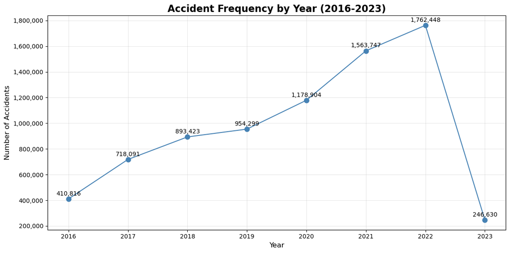

```python
# Extract year from start_time
df['year'] = df['start_time'].dt.year

# Count accidents by year
yearly_accidents = df['year'].value_counts().sort_index()

# Plot line chart
plt.figure(figsize=(12, 6))
plt.plot(yearly_accidents.index, yearly_accidents.values,
         marker='o', linewidth=1.5, markersize=8, color='steelblue')

# Add value labels on points
for year, count in yearly_accidents.items():
    plt.text(year, count + max(yearly_accidents.values)*0.01,
             f'{count:,.0f}', ha='center', va='bottom')

# Labeling
plt.title('Accident Frequency by Year (2016-2023)', fontsize=16, fontweight='bold')
plt.xlabel('Year', fontsize=12)
plt.ylabel('Number of Accidents', fontsize=12)

plt.gca().yaxis.set_major_formatter(plt.FuncFormatter(lambda x, p: f'{x:,.0f}'))
plt.grid(True, alpha=0.3)

# Ensure all years are shown
plt.xticks(yearly_accidents.index)
plt.tight_layout()

# Show plot
plt.show()
```

> **Observation:** The line chart shows rising trend in the accident counts with significant drop in 2023, which is not normal. Therfore, further investigations in the data pattern are required.

```python
# Check for sudden drop in 2023
print(f"Data range: {df['start_time'].min()} to {df['start_time'].max()}")
```

```
Data range: 2016-01-14 20:18:33 to 2023-03-31 23:30:00
```

```python
# Check accidents by month for each year
print("Accidents by month for each year:")
for year in [2021, 2022, 2023]:
    year_data = df[df['year'] == year]
    monthly_counts = year_data['start_time'].dt.month.value_counts().sort_index()
    print(f"\n{year} (Total: {len(year_data):,}):")
    for month, count in monthly_counts.items():
        print(f"  Month {month}: {count:,} accidents")
```

```
Accidents by month for each year:

2021 (Total: 1,563,747):
  Month 1: 152,914 accidents
  Month 2: 154,935 accidents
  Month 3: 90,643 accidents
  Month 4: 90,888 accidents
  Month 5: 101,731 accidents
  Month 6: 131,472 accidents
  Month 7: 113,333 accidents
  Month 8: 120,863 accidents
  Month 9: 134,874 accidents
  Month 10: 134,287 accidents
  Month 11: 157,729 accidents
  Month 12: 180,078 accidents

2022 (Total: 1,762,448):
  Month 1: 135,900 accidents
  Month 2: 163,839 accidents
  Month 3: 140,143 accidents
  Month 4: 196,687 accidents
  Month 5: 159,566 accidents
  Month 6: 129,264 accidents
  Month 7: 140,670 accidents
  Month 8: 152,361 accidents
  Month 9: 139,016 accidents
  Month 10: 85,135 accidents
  Month 11: 130,959 accidents
  Month 12: 188,908 accidents

2023 (Total: 246,630):
  Month 1: 160,914 accidents
  Month 2: 55,529 accidents
  Month 3: 30,187 accidents
```

> **Conclusion:** The plot and result are obvious now, since The data only goes up to March 31, 2023, so dataset only contains 3 months of data for 2023 compared to full years for previous years.

> **Excluding 2023:** Since the dataset contains only partial data up to March 2023, all 2023 records will be excluded to maintain consistent yearly analysis. This ensures that the insights are based on complete annual data without partial year bias.

```python
# Exclude 2023 data for consistent yearly analysis
df = df[df['start_time'].dt.year < 2023]
```

```python
# Verify data exclusion
print(f"Data range: {df['start_time'].min()} to {df['start_time'].max()}")
```

```
Data range: 2016-01-14 20:18:33 to 2022-12-31 23:59:03
```

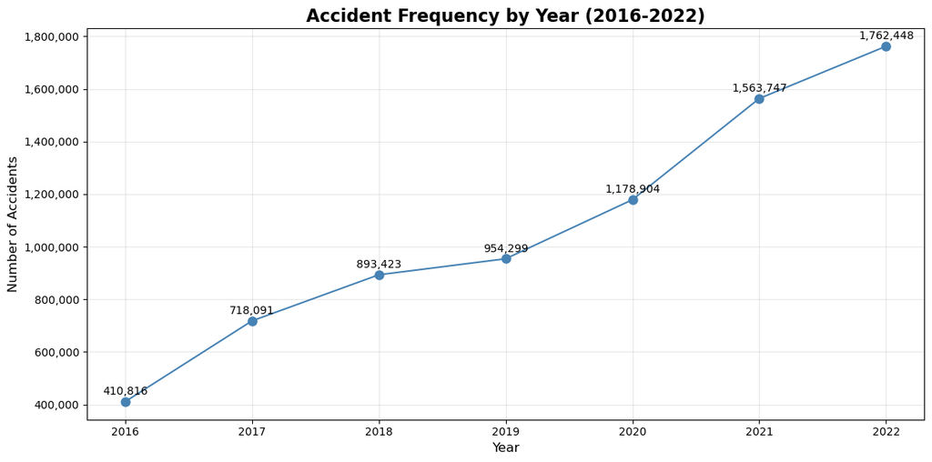

```python
# Verify data trend after excluding 2023 data
# Extract year from start_time
df['year'] = df['start_time'].dt.year

# Count accidents by year
yearly_accidents = df['year'].value_counts().sort_index()

# Plot line chart
plt.figure(figsize=(12, 6))
plt.plot(yearly_accidents.index, yearly_accidents.values,
         marker='o', linewidth=1.5, markersize=8, color='steelblue')

# Add value labels on points
for year, count in yearly_accidents.items():
    plt.text(year, count + max(yearly_accidents.values)*0.01,
             f'{count:,.0f}', ha='center', va='bottom')

# Labeling
plt.title('Accident Frequency by Year (2016-2022)', fontsize=16, fontweight='bold')
plt.xlabel('Year', fontsize=12)
plt.ylabel('Number of Accidents', fontsize=12)

plt.gca().yaxis.set_major_formatter(plt.FuncFormatter(lambda x, p: f'{x:,.0f}'))
plt.grid(True, alpha=0.3)

# Ensure all years are shown
plt.xticks(yearly_accidents.index)
plt.tight_layout()

# Show plot
plt.show()
```

**3.4: Check for Extreme Values**

**Extreme Value Checke** have been already conducted in the previous exercises. However, **Extremes** can be checked in diiferent ways, such:

- Interquartile Range (IQR) Method
- Using Z-scores (Standard Deviation Method)
- Visualization (boxplots & histograms) Method

A few random checks for **extreme values** with **"VISUALIZATION"** will be conducted for a few selected variables, which are critical to investigate the raod accident frequency in this case.

**- Extremes Value Checks for "temperature (f)"**

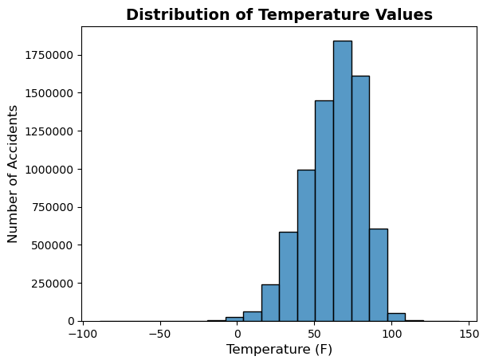

```python
# Visualizing extreme values for 'temperature(f)'
sns.histplot(df['temperature(f)'], bins=20, kde = False)
plt.title('Distribution of Temperature Values', fontsize = 14, fontweight = 'bold')
plt.xlabel('Temperature (F)', fontsize = 12)
plt.ylabel('Number of Accidents', fontsize = 12)

# Plotting y-axis value in normal number format
plt.ticklabel_format(style='plain', axis='y')

# Show histogram
plt.show()
```

**- Extremes Value Checks for "wind_chill (f)"**

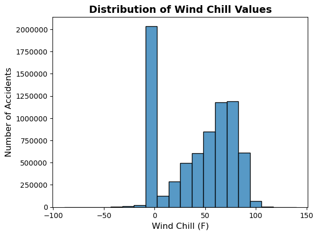

```python
sns.histplot(df['wind_chill(f)'], bins=20, kde = False)
plt.title('Distribution of Wind Chill Values', fontsize = 14, fontweight = 'bold')
plt.xlabel('Wind Chill (F)', fontsize = 12)
plt.ylabel('Number of Accidents', fontsize = 12)

# Plotting y-axis value in normal number format
plt.ticklabel_format(style='plain', axis='y')

# Show histogram
plt.show()
```

**- Extremes Value Checks for "humidity (%)"**

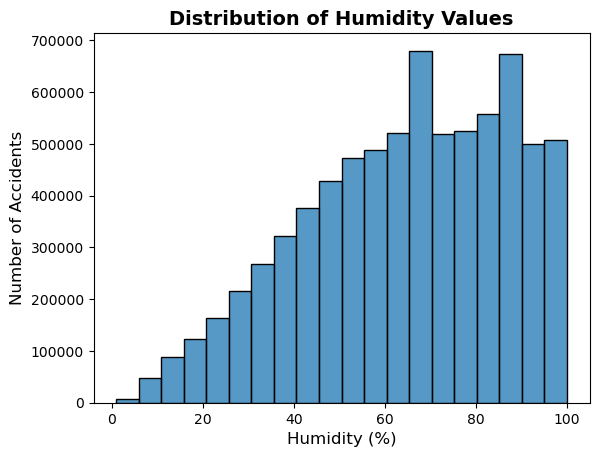

```python
sns.histplot(df['humidity(%)'], bins=20, kde = False)
plt.title('Distribution of Humidity Values', fontsize = 14, fontweight = 'bold')
plt.xlabel('Humidity (%)', fontsize = 12)
plt.ylabel('Number of Accidents', fontsize = 12)

# Plotting y-axis value in normal number format
plt.ticklabel_format(style='plain', axis='y')

# Show histogram
plt.show()
```

> **No Outliers** found for humidity, since the values lie between 0 and 100%.

**- Extremes Value Checks for "visibility (mi)"**

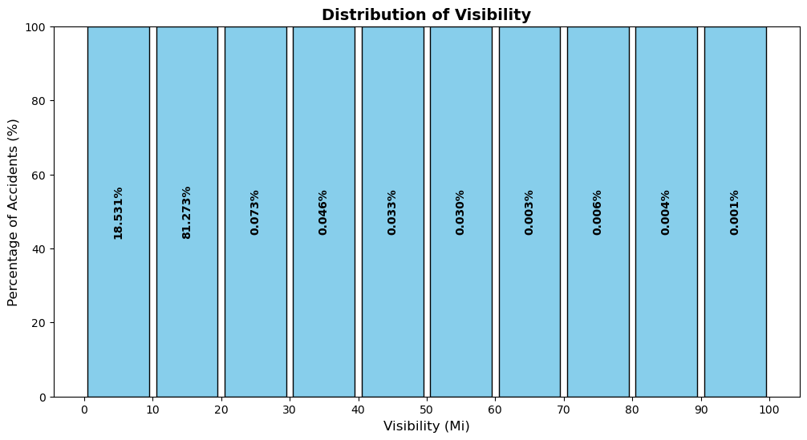

```python
# Histogram for visibility
from matplotlib.ticker import MultipleLocator  # import this

# Define bin edges (bin width 20)
min_vis = df['visibility(mi)'].min()
max_vis = df['visibility(mi)'].max()
bins = np.arange(min_vis, max_vis + 10, 10)

# Compute histogram
counts, bin_edges = np.histogram(df['visibility(mi)'], bins=bins)
percentages = counts / counts.sum() * 100

# Normalize counts to full height (100%)
normalized_heights = np.ones_like(counts) * 100  # full height bars

# Plot histogram with all bars full height
plt.figure(figsize=(12,6))
bars = plt.bar(
    (bin_edges[:-1] + bin_edges[1:]) / 2,  # bin centers
    normalized_heights,
    width=(bin_edges[1] - bin_edges[0]) * 0.9,
    color="skyblue",
    edgecolor="black"
)

# Add percentage text inside each bar (rotated 90°)
for bar, pct in zip(bars, percentages):
    if pct > 0:
        plt.text(
            bar.get_x() + bar.get_width()/2,
            50,                # middle of full-height bar
            f"{pct:.3f}%",
            ha="center",
            va="center",
            rotation=90,
            fontsize=10,
            fontweight="bold",
            color="black"
        )

# Titles & labels
plt.title("Distribution of Visibility", fontsize=14, fontweight="bold")
plt.xlabel("Visibility (Mi)", fontsize=12)
plt.ylabel("Percentage of Accidents (%)", fontsize=12)

# X-axis ticks every 10
plt.gca().xaxis.set_major_locator(MultipleLocator(10))

# Y-axis 0-100%
plt.ylim(0, 100)

plt.show()
```

**- Extremes Value Checks for "wind speed (mph)"**

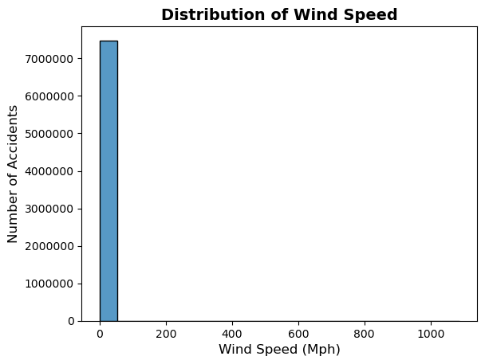

```python
# Histogram for wind speed
sns.histplot(df['wind_speed(mph)'], bins=20, kde = False)
plt.title('Distribution of Wind Speed', fontsize = 14, fontweight = 'bold')
plt.xlabel('Wind Speed (Mph)', fontsize = 12)
plt.ylabel('Number of Accidents', fontsize = 12)

# Plotting y-axis value in normal number format
plt.ticklabel_format(style='plain', axis='y')

# Show histogram
plt.show()
```

**- Extremes Value Checks for "precipitation (in)"**

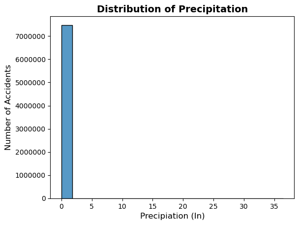

```python
# Histogram for precipitation(in)
sns.histplot(df['precipitation(in)'], bins=20, kde = False)
plt.title('Distribution of Precipitation', fontsize = 14, fontweight = 'bold')
plt.xlabel('Precipiation (In)', fontsize = 12)
plt.ylabel('Number of Accidents', fontsize = 12)

# Plotting y-axis value in normal number format
plt.ticklabel_format(style='plain', axis='y')

# Show histogram
plt.show()
```

> **Observations:** Based on meteorological knowledge and typical observed values in the U.S., following plausible ranges for selected variables in the U.S. road accident data analysis can be defined:
> - Temperatur (°F): −60 - 130 (Covers extreme Alaska lows to Death Valley high)
> - Wind Chill (°F): -80 - 130
> - Visibility (mi): 0 - 40 (0: No visibility (dense fog, blizzard), 10: Clear, > 40: Not meaningful (sky is clear)).
> - Wind Speed (mph): 0 - 120 (0: Calm, 60 - 100: Strong (Huricanes, Tornados, >120: Unlikely Outliers)
> - Precipitation (in): 0 - 6 (2 - 3: Heavy rainfall, 6: Unrealistic) --> inches/hour)

**- Cleaning Outliers**

```python
# Define plausible ranges
plausible_ranges = {
    'temperature(f)': (-60, 130),
    'wind_chill(f)': (-80, 130),
    'visibility(mi)': (0, 40),
    'wind_speed(mph)': (0, 120),
    'precipitation(in)': (0, 6)
}

# Make a copy of the dataframe to keep the original dataframe
df_drop = df.copy()

# Drop rows with outliers based on plausible ranges
for col, (low, high) in plausible_ranges.items():
    df_drop = df_drop[df_drop[col].between(low, high)]

print("Original dataframe shape:", df.shape)
print("Cleaned dataframe shape:", df_drop.shape)
```

```
Original dataframe shape: (7481728, 29)
Cleaned dataframe shape: (7477440, 29)
```

```python
# Shapes
original_shape = (7481728, 29)
cleaned_shape = (7477440, 29)

# Extract row counts
original_rows = original_shape[0]
cleaned_rows = cleaned_shape[0]

# Calculate dropped rows
dropped_rows = original_rows - cleaned_rows
dropped_pct = (dropped_rows / original_rows) * 100

# Print summary
print(f"{dropped_rows:,} ({dropped_pct:.2f}%) records dropped from original data")
```

```
4,288 (0.06%) records dropped from original data
```

**Precipitation vs. Accident Counts**

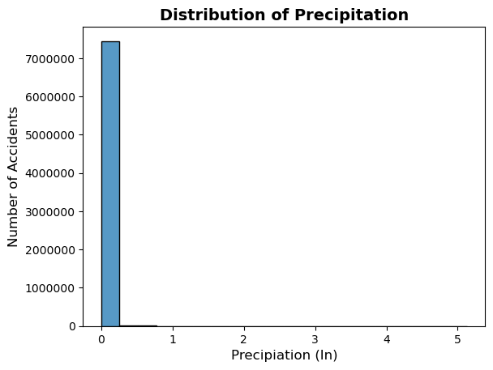

```python
# Histogram for precipitation(in) after data cleaning
sns.histplot(df_drop['precipitation(in)'], bins=20, kde = False)
plt.title('Distribution of Precipitation', fontsize = 14, fontweight = 'bold')
plt.xlabel('Precipiation (In)', fontsize = 12)
plt.ylabel('Number of Accidents', fontsize = 12)

# Plotting y-axis value in normal number format
plt.ticklabel_format(style='plain', axis='y')

# Show histogram
plt.show()
```

**Histogram: Accident Counts by Wind Speed**

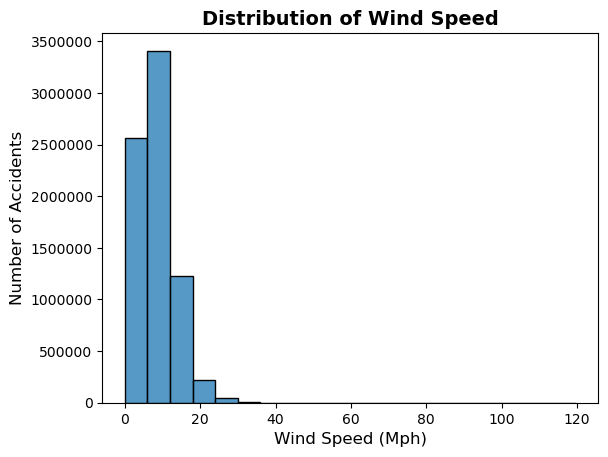

```python
# Histogram for wind speed after data cleaning
sns.histplot(df_drop['wind_speed(mph)'], bins=20, kde = False)
plt.title('Distribution of Wind Speed', fontsize = 14, fontweight = 'bold')
plt.xlabel('Wind Speed (Mph)', fontsize = 12)
plt.ylabel('Number of Accidents', fontsize = 12)

# Plotting y-axis value in normal number format
plt.ticklabel_format(style='plain', axis='y')

# Show histogram
plt.show()
```

### **4. Plotting Choropleth**

**4.1: Geographical concentration of accidents**

- **Hypothesis:** Certain states (e.g., CA, FL, TX) have disproportionately higher accident counts.

```python
# Aggregate number of accidents per state
data_to_plot = df_drop['state'].value_counts().reset_index()
data_to_plot.columns = ['state', 'count']  # 'count' = number of accidents

# Take log of counts for color scaling (handles large differences)
data_to_plot['log_count'] = np.log1p(data_to_plot['count'])  # log(1 + count)

# Reindex for attaching properties
state_data_indexed = data_to_plot.set_index('state')

# Setup Folium map centered on US
choropleth = folium.Map(location=[37.8, -96], zoom_start=4)

# Create choropleth with log_count
cp = folium.Choropleth(
    geo_data=usa_geo,                   # GeoJSON for US states
    data=data_to_plot,
    columns=['state', 'log_count'],     # use log_count for coloring
    key_on='feature.properties.name',
    fill_color='YlOrRd',                # yellow-orange-red color scale
    fill_opacity=0.7,
    line_opacity=0.2,
    legend_name='Number of Accidents',  # indicate log scale
    nan_fill_color="white"
).add_to(choropleth)

# Attach actual accident counts to each state for tooltip
for s in cp.geojson.data['features']:
    state_name = s['properties']['name']
    if state_name in state_data_indexed.index:
        s['properties']['count'] = int(state_data_indexed.loc[state_name, 'count'])
    else:
        s['properties']['count'] = 0

# Add tooltip (shows actual count on hover)
folium.GeoJsonTooltip(
    fields=['name', 'count'],
    aliases=['State:', 'Accidents:'],
    localize=True
).add_to(cp.geojson)

# Add layer control
folium.LayerControl().add_to(choropleth)

# Display map
choropleth
```

Make this Notebook Trusted to load map: File -> Trust Notebook

[interactive chart not shown]

> **Observation:**
- > **Hotspots:** States like **California (CA)** and **Florida (FL)** clearly stand out with the darkest shades, indicating a significantly higher number of accidents compared to most other states. This strongly supports the **hypothesis** that these **states are hotspots for accidents.**
- > **Other High Concentration Areas:** Maps shows medium-concentration of accident frequency in **Texas** and other eastern states such as **NY, PA, NJ.**
- > **Low Concentration Areas:** Most of the central and northern U.S. states, including the Midwest and the Mountain West, are shown in very light shades or white, indicating a much lower number of accidents.
- > **Alska + Hawaii:** As mentioned previously, states **Alaska and Hawaii** are not in the scope of this anaylsis due to missing data.

**4.2: Severity distribution across states**

- **Hypothesis:** Severe accidents (Serious/Major) occur more frequently in some states than others.

```python
# Filter only severe accidents (Serious/Major)
severe_accidents = df_drop[df_drop['severity_label'].isin(['Serious', 'Major'])]

# Count severe accidents per state
severe_counts = severe_accidents['state'].value_counts().reset_index()
severe_counts.columns = ['state', 'severe_count']

# Count total accidents per state (for normalization)
total_counts = df_drop['state'].value_counts().reset_index()
total_counts.columns = ['state', 'total_count']

# Merge severe and total counts
state_severity = pd.merge(severe_counts, total_counts, on='state', how='right')
state_severity['severe_count'] = state_severity['severe_count'].fillna(0)

# Calculate proportion of severe accidents
state_severity['severe_ratio'] = state_severity['severe_count'] / state_severity['total_count']

# Reindex for attaching properties later
state_data_indexed = state_severity.set_index('state')

# Setup Folium map
choropleth = folium.Map(location=[37.8, -96], zoom_start=4)

# Create choropleth based on severe_ratio
cp = folium.Choropleth(
    geo_data=usa_geo,
    data=state_severity,
    columns=['state', 'severe_ratio'],
    key_on='feature.properties.name',   # must match GeoJSON 'name'
    fill_color='YlOrRd',
    fill_opacity=0.7,
    line_opacity=0.2,
    legend_name='Proportion of Severe Accidents'
).add_to(choropleth)

# Attach severe_ratio + counts to each state polygon for tooltip
for s in cp.geojson.data['features']:
    state_name = s['properties']['name']
    if state_name in state_data_indexed.index:
        s['properties']['severe_ratio']  = round(state_data_indexed.loc[state_name, 'severe_ratio'], 3)
        s['properties']['severe_count']  = int(state_data_indexed.loc[state_name, 'severe_count'])
        s['properties']['total_count']   = int(state_data_indexed.loc[state_name, 'total_count'])
    else:
        s['properties']['severe_ratio']  = 0
        s['properties']['severe_count']  = 0
        s['properties']['total_count']   = 0

# Add tooltip (hover popup)
folium.GeoJsonTooltip(
    fields=['name', 'severe_count', 'total_count', 'severe_ratio'],
    aliases=['State:', 'Severe accidents:', 'Total accidents:', 'Severe ratio:'],
    localize=True
).add_to(cp.geojson)

# Layer control
folium.LayerControl().add_to(choropleth)

# Display map
choropleth
```

Make this Notebook Trusted to load map: File -> Trust Notebook

[interactive chart not shown]

- > Highest Severity (Major/Serious) Rates: Northeastern states show darkest shading (0.31-0.46 range)
- > Moderate Severity: Midwest and some Western states (CA, TX) with medium proportions
- > Lower Severity: Southeastern and Mountain West states with lighter shading

> **Key Insights** for further analysis:

> **Observation:** This map shows the normalized proportions of severe accidents **(Major, Serious)** per state.
- > Population density doesn't directly correlate with severity rates
- > High total accidents ≠ high severity proportions (CA/TX vs. Northeast)
- *Note: Alaska and Hawaii excluded from analysis due to data limitations*

**4.3: Seasonal/Monthly accident variation by state**

- **Hypothesis:** Northern states see higher accident frequencies in winter months (snow/ice), while southern states see peaks in summer (heat/storms).

```python
# Define winter months
winter_months = ['November', 'December', 'January', 'February']

# Filter accidents for winter months
winter_accidents = df_drop[df_drop['month_name'].isin(winter_months)]

# Count accidents per state in winter
winter_counts = winter_accidents['state'].value_counts().reset_index()
winter_counts.columns = ['state', 'winter_count']

# Count total accidents per state (for normalization)
total_counts = df_drop['state'].value_counts().reset_index()
total_counts.columns = ['state', 'total_count']

# Merge winter and total counts
state_winter = pd.merge(winter_counts, total_counts, on='state', how='right')
state_winter['winter_count'] = state_winter['winter_count'].fillna(0)

# Calculate proportion of winter accidents per state
state_winter['winter_ratio'] = state_winter['winter_count'] / state_winter['total_count']

# Reindex for attaching properties
state_data_indexed = state_winter.set_index('state')

# Setup folium map
choropleth = folium.Map(location=[37.8, -96], zoom_start=4)

# Create choropleth based on winter_ratio
cp = folium.Choropleth(
    geo_data=usa_geo,
    data=state_winter,
    columns=['state', 'winter_ratio'],
    key_on='feature.properties.name',
    fill_color='PuBu',        # Color scale (purple-blue)
    fill_opacity=0.7,
    line_opacity=0.2,
    legend_name='Proportion of Accidents in Winter (Nov-Feb)'
).add_to(choropleth)

# Attach winter stats to polygons for tooltip
for s in cp.geojson.data['features']:
    state_name = s['properties']['name']
    if state_name in state_data_indexed.index:
        s['properties']['winter_ratio']  = round(state_data_indexed.loc[state_name, 'winter_ratio'], 3)
        s['properties']['winter_count']  = int(state_data_indexed.loc[state_name, 'winter_count'])
        s['properties']['total_count']   = int(state_data_indexed.loc[state_name, 'total_count'])
    else:
        s['properties']['winter_ratio']  = 0
        s['properties']['winter_count']  = 0
        s['properties']['total_count']   = 0

# Add tooltip (hover popup)
folium.GeoJsonTooltip(
    fields=['name', 'winter_count', 'total_count', 'winter_ratio'],
    aliases=['State:', 'Winter accidents:', 'Total accidents:', 'Winter ratio:'],
    localize=True
).add_to(cp.geojson)

# Layer control
folium.LayerControl().add_to(choropleth)

# Display map
choropleth
```

Make this Notebook Trusted to load map: File -> Trust Notebook

[interactive chart not shown]

> **Observation:** The map clearly highlights the regional differences in winter accident proportions, making ti easy to see the correlation between colder climates and a higher share of accidents during winter. Further analysis needed for verification.
- > **Higher Winter Accident Proportion in Northern States:** States like North Dakota, South Dakota, Minnesota, Wisconsin, and Michigan exhibit a higher proportion of accidents during the winter months (November-February).
- > **Lower Winter Accident Proportion in Southern States:** Southern states, including Florida, Texas, California, and Arizona, show a lower proportion of accidents in the winter months.
- > **Regional Variation:** The map illustrates a clear regional pattern where the share of total accidents occurring in winter is higher in the northern U.S. and lower in the southern U.S.

### Research Questions from Previous Step

#### **Geographical Analysis**

1. **Which geographic areas (state) have the highest concentration of severe accidents?**
   - The highest concentration of accidents occurs in California (22.5%), while Wyoming, North Dakota, South Dakota, Maine, and Vermont report the lowest, with 0% of accidents.
2. How do accident patterns differ between urban and rural settings?
3. Which specific street types or locations show recurring accident patterns?
4. Which areas have the highest density of accidents near amenities and stations?
5. How do accident patterns differ across time zones and regions?

##### **Severity & Impact Analysis**

6. **What weather conditions are most strongly associated with high-severity accidents?**
   - High-severity accidents (Serious and Major) are most frequently associated with fair and clear weather conditions.
7. **What combination of time, weather, and location factors predicts high-severity accidents?**
   - Accident severity does not show a direct correlation with visibility conditions. However, accident frequencies exhibit clear temporal patterns: they peak during the morning hours of 6–8 AM and the afternoon period of 3–5 PM, coinciding with typical rush hour traffic when commuter volume is highest. In contrast, late morning to early afternoon hours experience a notable decline in accidents, reflecting lower traffic density outside peak commuting times. These trends suggest that time of day and traffic volume play a more significant role in accident occurrence than visibility alone.
8. How does accident severity correlate with visibility conditions and time of day?
9. Can we identify specific weather condition thresholds that trigger increased accident risk?
10. What are the most common weather and time combinations for severe accidents in different regions?

#### **Temporal Patterns & Trends**

11. **What are the peak periods for road accidents across daily, weekly, and seasonal cycles?**
    - Accidents peak during morning (6–8 AM) and afternoon (3–5 PM) rush hours on weekdays, which have significantly higher rates (15.7%–17.7%) than weekends. Winter months, especially December (11.7%) and January (9.7%), show the highest frequency.
12. **What is the trend in accident frequency and severity from 2016-2023?**
    - Accident frequency increased steadily from 2016 to 2022, while severity distribution remained consistent—dominated by minor accidents, followed by moderate, serious, and major incidents.
13. What is the relationship between temperature extremes and accident occurrence?

### **5. Summary**

**Answers to Research Questions:**

**Q6:** This question is directly answered: "High-severity accidents (Serious and Major) are most frequently associated with fair and clear weather conditions."

**New research questions:**

- Why do severe accidents occur more in fair weather?
- Since the map indicates lower winter accident proportions in southern states, what are their peak seasons for accidents, and what weather/environmental factors contribute to those peaks (e.g., summer storms, heat-related issues)?
- What role does population density versus total population play in accident concentration?
- What specific mitigation strategies are most effective in states with consistently high accident frequencies and those with high winter proportions?

**Export cleaned dataframe**

```python
# Export final dataframe "Cleaned Data" as pickle

df_drop.to_pickle(os.path.join(path, '02 Data', 'Prepared Data', 'us_accidents_6-3.pkl'))
```